# ML ASS 4 UL PENGUINS

KIBIDI

2026-04-14

## R Markdown

Course: PROFFESIONAL CERTIFICATE IN DATA ANALYSIS, MACHINE LEARNING AND AI Instructor: Lumumba W. Victor Email: lumumbavictor172@gmail.com

student: KIBIDI LERENCER Reg no: CDAM/0047/2026 Email: kabeyi24leren@gmail.com

Date Issued: April 13, 2026

#set working directory

```r
setwd("C:/Users/h6p/Desktop/submit")
```

3.1 Task 1: Data Import and Exploration (10 Marks) #3.1.1. Load all necessary libraries (tidyverse, palmerpenguins, cluster, factoextra).

```r
library(tidyverse)      # Data manipulation andvisualization
library(palmerpenguins) # Built-in penguins dataset
library(cluster)        # Silhouette analysis
library(factoextra)     # PCA and clustering visualization
```

```r
library(ggplot2)        # Advanced plotting
library(dplyr)          # Data wrangling
library(NbClust)
library(mclust)
```

#3.1.2. Load th epenguins dataset using data(“penguins”, package = “palmerpenguins”).

```r
data("penguins", package = "palmerpenguins")
```

#3.1.3a) Display the structure

```r
 str(penguins)
```

```
## tibble [344 × 8] (S3: tbl_df/tbl/data.frame)
##  $ species          : Factor w/ 3 levels "Adelie","Chinstrap",..: 1 1 1 1 1 1 1 1 1 1 ...
##  $ island           : Factor w/ 3 levels "Biscoe","Dream",..: 3 3 3 3 3 3 3 3 3 3 ...
##  $ bill_length_mm   : num [1:344] 39.1 39.5 40.3 NA 36.7 39.3 38.9 39.2 34.1 42 ...
##  $ bill_depth_mm    : num [1:344] 18.7 17.4 18 NA 19.3 20.6 17.8 19.6 18.1 20.2 ...
##  $ flipper_length_mm: int [1:344] 181 186 195 NA 193 190 181 195 193 190 ...
##  $ body_mass_g      : int [1:344] 3750 3800 3250 NA 3450 3650 3625 4675 3475 4250 ...
##  $ sex              : Factor w/ 2 levels "female","male": 2 1 1 NA 1 2 1 2 NA NA ...
##  $ year             : int [1:344] 2007 2007 2007 2007 2007 2007 2007 2007 2007 2007 ...
```

#3.1.3b)summary statistics

```r
summary(penguins)
```

```
##       species          island    bill_length_mm  bill_depth_mm
##  Adelie   :152   Biscoe   :168   Min.   :32.10   Min.   :13.10
##  Chinstrap: 68   Dream    :124   1st Qu.:39.23   1st Qu.:15.60
##  Gentoo   :124   Torgersen: 52   Median :44.45   Median :17.30
##                                  Mean   :43.92   Mean   :17.15
##                                  3rd Qu.:48.50   3rd Qu.:18.70
##                                  Max.   :59.60   Max.   :21.50
##                                  NA's   :2       NA's   :2
##  flipper_length_mm  body_mass_g       sex           year
##  Min.   :172.0     Min.   :2700   female:165   Min.   :2007
##  1st Qu.:190.0     1st Qu.:3550   male  :168   1st Qu.:2007
##  Median :197.0     Median :4050   NA's  : 11   Median :2008
##  Mean   :200.9     Mean   :4202                Mean   :2008
##  3rd Qu.:213.0     3rd Qu.:4750                3rd Qu.:2009
##  Max.   :231.0     Max.   :6300                Max.   :2009
##  NA's   :2         NA's   :2
```

#3.1.4a) Check for missing values and report the count and percentage per variable.

```r
colSums(is.na(penguins))
```

```
##           species            island    bill_length_mm     bill_depth_mm
##                 0                 0                 2                 2
## flipper_length_mm       body_mass_g               sex              year
##                 2                 2                11                 0
```

```r
sum(is.na(penguins)) / (nrow(penguins) * ncol(penguins)) * 100
```

```
## [1] 0.690407
```

#3.1.4)summary of missing data

```r
missing_summary <- data.frame(
  Variable = names(penguins),
  Missing_Count = colSums(is.na(penguins)),
  Missing_Percent = colMeans(is.na(penguins)) * 100
)

missing_summary
```

```
##                            Variable Missing_Count Missing_Percent
## species                     species             0       0.0000000
## island                       island             0       0.0000000
## bill_length_mm       bill_length_mm             2       0.5813953
## bill_depth_mm         bill_depth_mm             2       0.5813953
## flipper_length_mm flipper_length_mm             2       0.5813953
## body_mass_g             body_mass_g             2       0.5813953
## sex                             sex            11       3.1976744
## year                           year             0       0.0000000
```

#3.1.5. Create a clean dataset by removing rows with missing values: .

```r
penguins_clean <-na.omit(penguins)
dim(penguins_clean)
```

```
## [1] 333   8
```

#3.1.5b)verify penguin clean has no missing data

```r
missing_summary <- data.frame(
  Variable = names(penguins_clean),
  Missing_Count = colSums(is.na(penguins_clean)),
  Missing_Percent = colMeans(is.na(penguins_clean)) * 100
)

missing_summary
```

```
##                            Variable Missing_Count Missing_Percent
## species                     species             0               0
## island                       island             0               0
## bill_length_mm       bill_length_mm             0               0
## bill_depth_mm         bill_depth_mm             0               0
## flipper_length_mm flipper_length_mm             0               0
## body_mass_g             body_mass_g             0               0
## sex                             sex             0               0
## year                           year             0               0
```

3.2 Task 2: Data Preprocessing (15 Marks)

#3.2.1. Select only numeric morphological variables for analysis: • bill_length_mm, bill_depth_mm, flipper_length_mm, body_mass_g

```r
numeric_vars <- c("bill_length_mm", "bill_depth_mm","flipper_length_mm", "body_mass_g")
 penguins_numeric <- penguins_clean[, numeric_vars]
```

#3.2.2. Scale these variables to mean = 0 and standard deviation = 1 using scale(). #3.2.3. Create a new dataframe penguins_scaled containing only the scaled numeric variables.

```r
 penguins_scaled <- as.data.frame(scale(penguins_numeric))
```

#3.2.4. Verify scaling

```r
colMeans(penguins_scaled) # Should be ~0
```

```
##    bill_length_mm     bill_depth_mm flipper_length_mm       body_mass_g
##      3.552797e-16      5.572578e-16      1.834379e-16     -9.274780e-17
```

```r
apply(penguins_scaled, 2, sd) # Should be ~1
```

```
##    bill_length_mm     bill_depth_mm flipper_length_mm       body_mass_g
##                 1                 1                 1                 1
```

#3.2.5. Document why scaling is critical for K-Means and PCA K-Means and PCA use Euclidean distance; unscaled variables with larger ranges (e.g., body_mass_g) would dominate the analysis

3.3 Task 3: Exploratory Data Visualization (10 Marks)

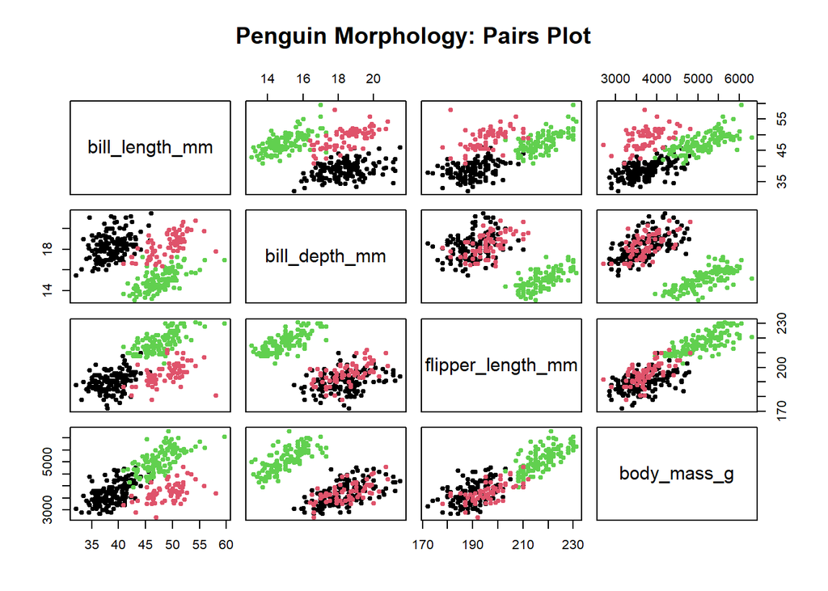

```r
 pairs(penguins_numeric,
       col = as.numeric(penguins_clean$species),
pch = 19, cex = 0.7,
main = "Penguin Morphology: Pairs Plot")
```

#3.3.2. Generate boxplots for each numeric variable grouped by species to visualize between species differences.

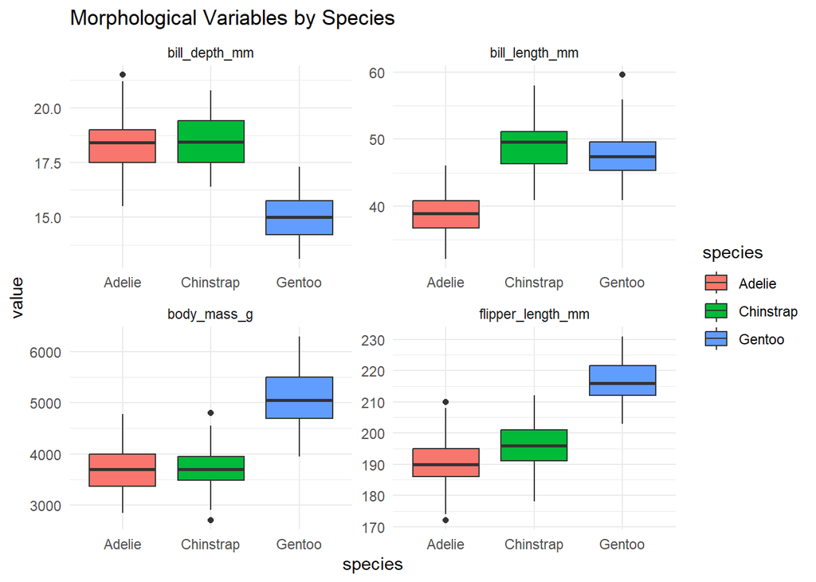

```r
penguins_clean %>%
  pivot_longer(cols = all_of(numeric_vars),
               names_to = "variable", values_to = "value") %>%
  ggplot(aes(x = species, y = value, fill = species)) +
  geom_boxplot() +
  facet_wrap(~variable, scales = "free") +
  theme_minimal() +
  labs(title = "Morphological Variables by Species")
```

#3.3.3. Compute and report the correlation matrix of the four numeric variables.

```r
 cor(penguins_numeric)
```

```
##                   bill_length_mm bill_depth_mm flipper_length_mm body_mass_g
## bill_length_mm         1.0000000    -0.2286256         0.6530956   0.5894511
## bill_depth_mm         -0.2286256     1.0000000        -0.5777917  -0.4720157
## flipper_length_mm      0.6530956    -0.5777917         1.0000000   0.8729789
## body_mass_g            0.5894511    -0.4720157         0.8729789   1.0000000
```

#3.3.4. Discuss which variables appear most useful for distinguishing groups

3.4 Task 4: K-Means: Finding Optimal K (10 Marks)

#3.4.1. Apply the elbow method: run K-Means for k = 1 to 10 and plot total within-clustersum of squares (WSS) vs. k.

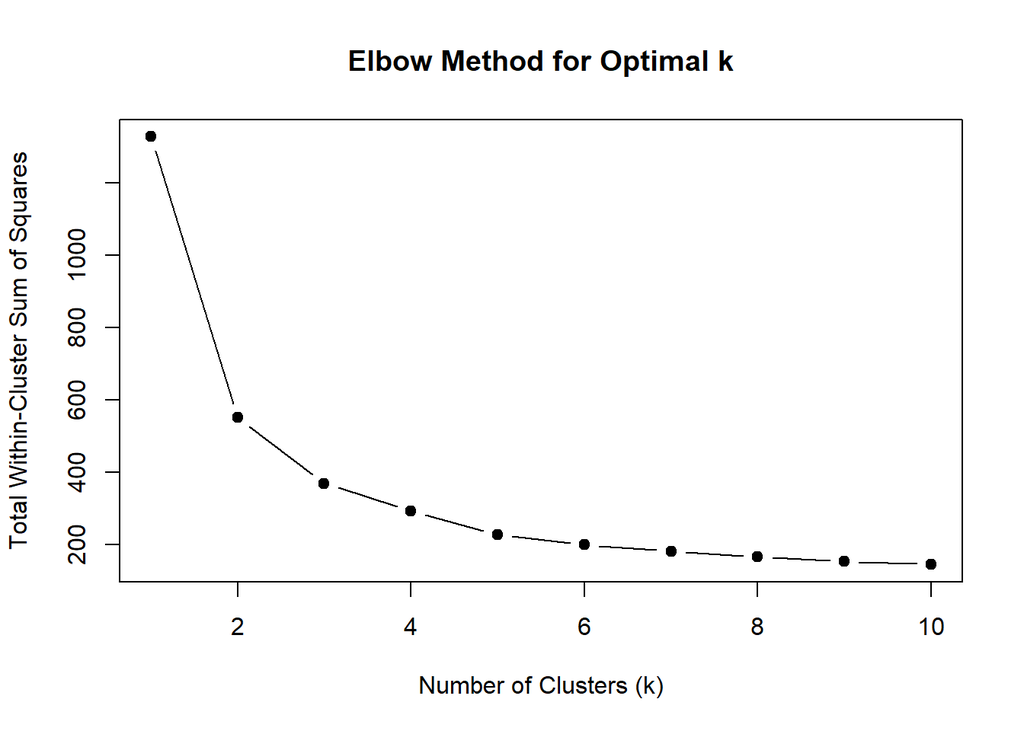

```r
 set.seed(2026)

# Elbow method
wss <- map_dbl(1:10, ~{
  kmeans(penguins_scaled, centers = .x, nstart = 25)$tot.withinss
})

plot(1:10, wss, type = "b", pch = 19,
      xlab = "Number of Clusters (k)",
      ylab = "Total Within-Cluster Sum of Squares",
      main = "Elbow Method for Optimal k")
```

#3.4.2. Apply silhouette analysis: compute average silhouette width for k = 2 to 10 andplot results.

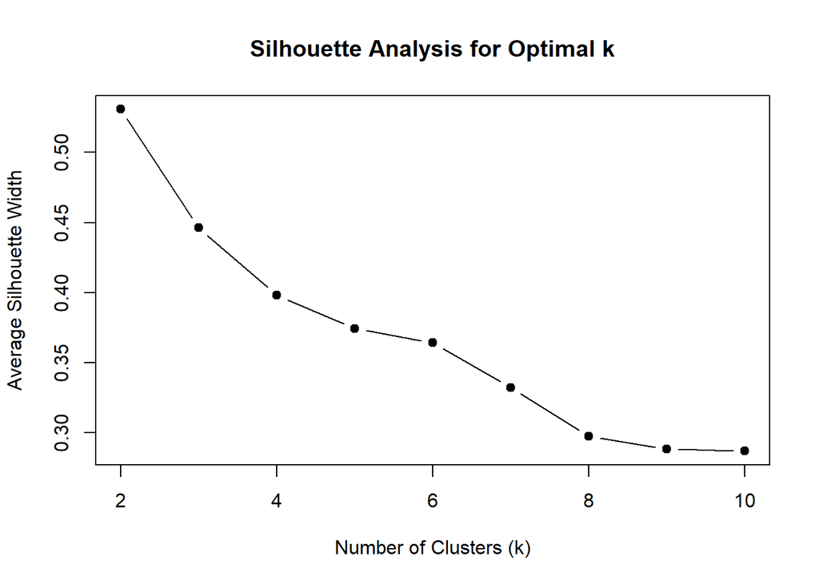

```r
# Silhouette analysis
sil_width <- map_dbl(2:10, ~{
  km <- kmeans(penguins_scaled, centers = .x, nstart = 25)
  silhouette(km$cluster, dist(penguins_scaled)) %>%
    summary() %>%
    `[[`("avg.width")
})

plot(2:10, sil_width, type = "b", pch = 19,
      xlab = "Number of Clusters (k)",
      ylab = "Average Silhouette Width",
      main = "Silhouette Analysis for Optimal k")
```

#3.4.2b.

[figure not shown]

```r
ggplot(penguins_scaled, aes(x = bill_length_mm, y = bill_depth_mm,
                            color = penguins_clean$cluster)) +
  geom_point(size = 2, alpha = 0.7) +
  labs(title = "K-Means Clusters: First Two Scaled Variables",
       x = "Bill Length (scaled)", y = "Bill Depth (scaled)") +
  theme_minimal()
```

#3.4.4. Report the total WSS and average silhouette width for your chosen k

```r
# Set seed for reproducibility
set.seed(2026)

# Fit K-Means with k=3
k_opt <- 3
km_model <- kmeans(penguins_scaled, centers = k_opt, nstart = 25)

# Extract Total WSS
total_wss <- km_model$tot.withinss
cat("Total Within-Cluster Sum of Squares (WSS):", round(total_wss, 2), "\n")
```

```
## Total Within-Cluster Sum of Squares (WSS): 369.65
```

```r
# Extract Average Silhouette Width
sil <- silhouette(km_model$cluster, dist(penguins_scaled))
avg_sil_width <- mean(sil[, 3])
cat("Average Silhouette Width:", round(avg_sil_width, 3), "\n")
```

```
## Average Silhouette Width: 0.446
```

3.5 Task 5: K-Means: Model Fitting and Cluster Profiling (15 Marks) #3.5.1. Fit the final K-Means model using your optimal k and nstart = 25 for stability.

```r
set.seed(2026)
k_opt <- 3
km_model <- kmeans(penguins_scaled, centers = k_opt, nstart =25)
```

#3.5.2. Add the cluster assignments to the original penguins_clean dataframe.

```r
penguins_clean$cluster <- as.factor(km_model$cluster)
str(penguins_clean)
```

```
## tibble [333 × 9] (S3: tbl_df/tbl/data.frame)
##  $ species          : Factor w/ 3 levels "Adelie","Chinstrap",..: 1 1 1 1 1 1 1 1 1 1 ...
##  $ island           : Factor w/ 3 levels "Biscoe","Dream",..: 3 3 3 3 3 3 3 3 3 3 ...
##  $ bill_length_mm   : num [1:333] 39.1 39.5 40.3 36.7 39.3 38.9 39.2 41.1 38.6 34.6 ...
##  $ bill_depth_mm    : num [1:333] 18.7 17.4 18 19.3 20.6 17.8 19.6 17.6 21.2 21.1 ...
##  $ flipper_length_mm: int [1:333] 181 186 195 193 190 181 195 182 191 198 ...
##  $ body_mass_g      : int [1:333] 3750 3800 3250 3450 3650 3625 4675 3200 3800 4400 ...
##  $ sex              : Factor w/ 2 levels "female","male": 2 1 1 1 2 1 2 1 2 2 ...
##  $ year             : int [1:333] 2007 2007 2007 2007 2007 2007 2007 2007 2007 2007 ...
##  $ cluster          : Factor w/ 3 levels "1","2","3": 2 2 2 2 2 2 2 2 2 2 ...
##  - attr(*, "na.action")= 'omit' Named int [1:11] 4 9 10 11 12 48 179 219 257 269 ...
##   ..- attr(*, "names")= chr [1:11] "4" "9" "10" "11" ...
```

#3.5.3. Compute cluster centroids (mean of each scaled variable per cluster).

```r
 km_model$centers
```

```
##   bill_length_mm bill_depth_mm flipper_length_mm body_mass_g
## 1      0.6537742    -1.1010497         1.1607163   1.0995561
## 2     -1.0452359     0.4858944        -0.8803701  -0.7616078
## 3      0.6710153     0.8040534        -0.2889118  -0.3835267
```

#3.5.4. Profile each cluster by computing mean values of original (unscaled) variables per cluster. #3.5.5. Create a table summarizing cluster characteristics (size, centroid values, dominant species if known).

```r
 penguins_clean %>%
  group_by(cluster) %>%
  summarise(across(all_of(numeric_vars), mean, na.rm = TRUE),
            n = n())
```

```
## # A tibble: 3 × 6
##   cluster bill_length_mm bill_depth_mm flipper_length_mm body_mass_g     n
##   <fct>            <dbl>         <dbl>             <dbl>       <dbl> <int>
## 1 1                 47.6          15.0              217.       5092.   119
## 2 2                 38.3          18.1              189.       3594.   129
## 3 3                 47.7          18.7              197.       3898.    85
```

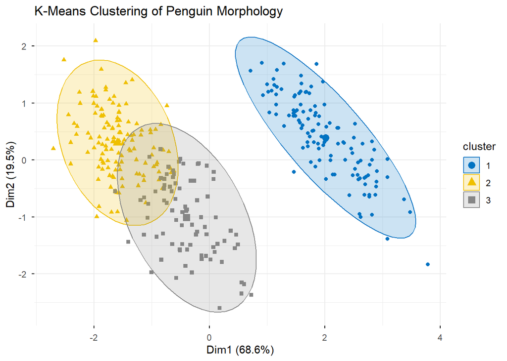

```r
fviz_cluster(km_model, data = penguins_scaled,
             geom = "point", ellipse.type = "norm",
             palette = "jco", ggtheme = theme_minimal(),
             main = "K-Means Clustering of Penguin Morphology")
```

#COUNTS

```r
table(penguins_clean$cluster)
```

```
##
##   1   2   3
## 119 129  85
```

3.6 Task 6: Principal Component Analysis (PCA) (15 Marks)

#3.6.1. Perform PCA on the scaled numeric variables using prcomp().

```r
pca_result <- prcomp(penguins_scaled, center = TRUE, scale. =TRUE)

# Summary and variance
summary(pca_result)
```

```
## Importance of components:
##                           PC1    PC2     PC3     PC4
## Standard deviation     1.6569 0.8821 0.60716 0.32846
## Proportion of Variance 0.6863 0.1945 0.09216 0.02697
## Cumulative Proportion  0.6863 0.8809 0.97303 1.00000
```

```r
pca_result$sdev^2 / sum(pca_result$sdev^2) # Proportion of variance
```

```
## [1] 0.68633893 0.19452929 0.09216063 0.02697115
```

#3.6.2. Generate and interpret the scree plot: report the proportion of variance explained by each PC.

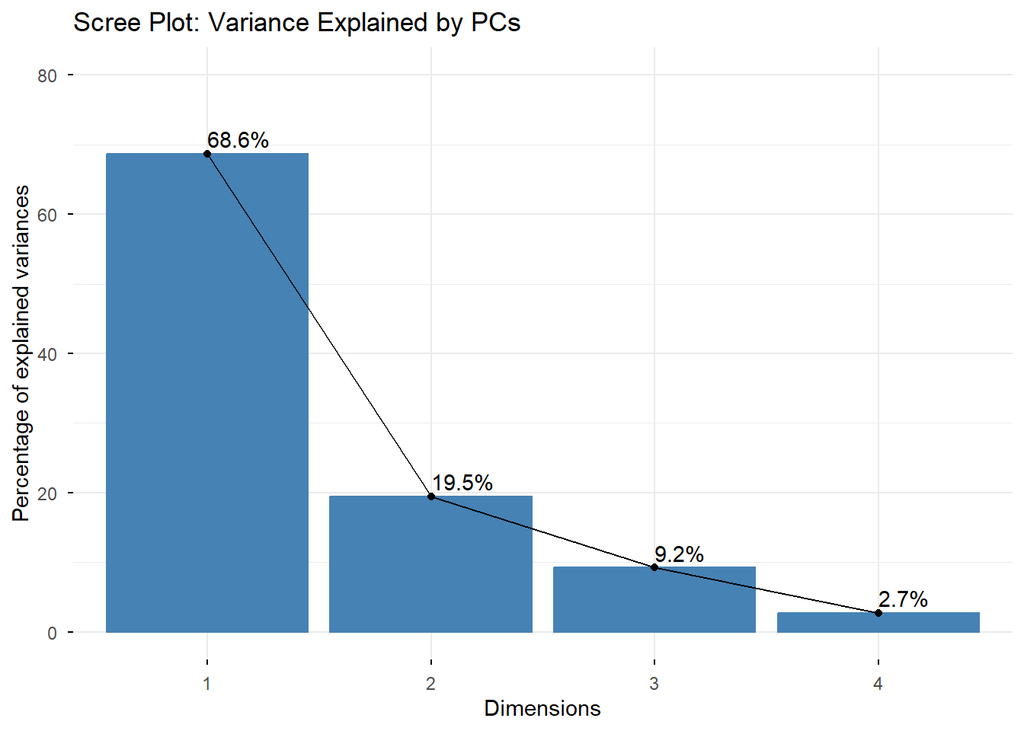

```r
fviz_eig(pca_result, addlabels = TRUE, ylim = c(0, 80),
         main = "Scree Plot: Variance Explained by PCs")
```

#3.6.3. Determine how many principal components are needed to explain at least 90% of total variance.

```r
var_prop <- pca_result$sdev^2 / sum(pca_result$sdev^2)
cum_var <- cumsum(var_prop)
pcs_90 <- which(cum_var >= 0.90)[1]
cat("PCs needed for ≥90% variance:", pcs_90, "\n")
```

```
## PCs needed for ≥90% variance: 3
```

```r
cat("Cumulative variance explained:", round(cum_var[pcs_90]*100, 2), "%\n")
```

```
## Cumulative variance explained: 97.3 %
```

#3.6.4. Extract and interpret the loadings (rotation matrix) for PC1 and PC2.

```r
pca_result$rotation[, 1:2]
```

```
##                          PC1         PC2
## bill_length_mm     0.4537532 -0.60019490
## bill_depth_mm     -0.3990472 -0.79616951
## flipper_length_mm  0.5768250 -0.00578817
## body_mass_g        0.5496747 -0.07646366
```

#3.6.5. Create a biplot showing observations and variable loadings in PC1-PC2 space

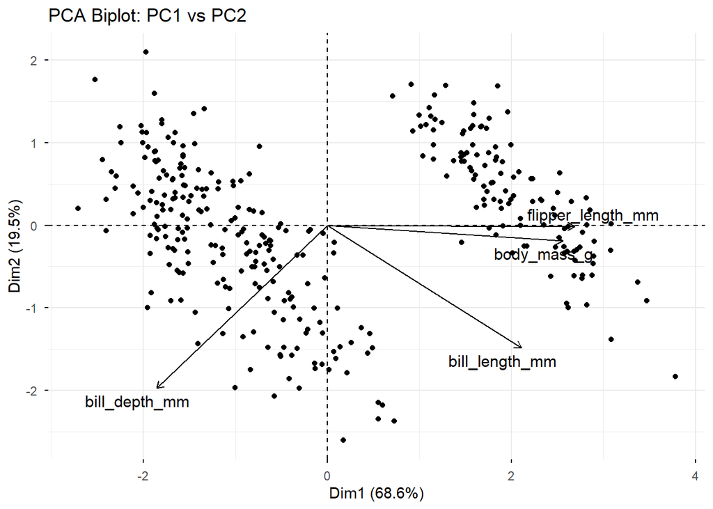

```r
fviz_pca_biplot(pca_result,
                label = "var",
                habillage = "none",
                addEllipses = FALSE,
                col.var = "black",
                repel = TRUE) +
  ggtitle("PCA Biplot: PC1 vs PC2")
```

3.7 Task 7: Combining K-Means and PCA (15 Marks)

#3.7.1. Project the scaled data onto the first two principal components.

```r
pca_scores <- as.data.frame(pca_result$x[, 1:2])
colnames(pca_scores) <- c("PC1", "PC2")
```

#3.7.2. Re-run K-Means clustering on the first two PCs only (using your optimal k).

```r
set.seed(2026)
km_pca <- kmeans(pca_scores, centers = k_opt, nstart = 25)
```

#3.7.3. Compare cluster assignments from PCA-reduced data vs. original 4-dimensionaldata (use a confusion matrix).

```r
 table(FullSpace = km_model$cluster, PCspace = km_pca$cluster)
```

```
##          PCspace
## FullSpace   1   2   3
##         1 119   0   0
##         2   0 119  10
##         3   0   3  82
```

#3.7.4. Create a scatter plot of PC1 vs. PC2, colored by: • K-Means cluster assignment (from full data) • Original species (for validation reference only)

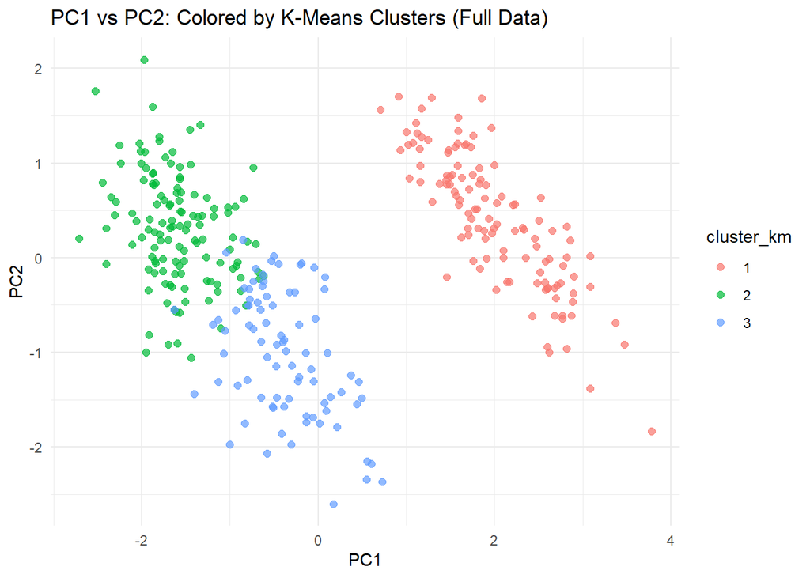

```r
pca_scores$cluster_km <- as.factor(km_model$cluster)
  ggplot(pca_scores, aes(x = PC1, y = PC2, color = cluster_km))+
  geom_point(size = 2, alpha = 0.7) +
  theme_minimal() +
  labs(title = "PC1 vs PC2: Colored by K-Means Clusters (Full Data)")
```

#3.7.5. Discuss whether PCA preserves the cluster structure found in the full-dimensional space.

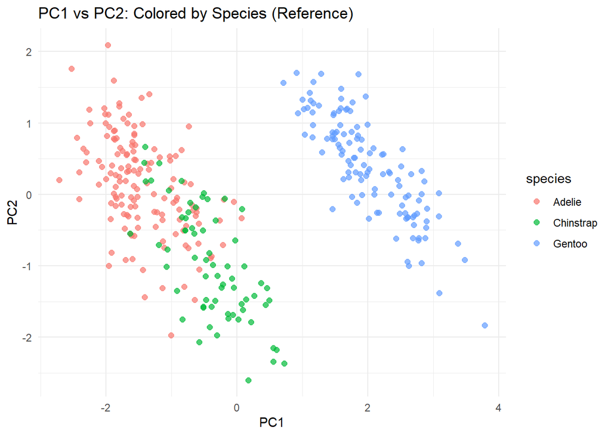

```r
pca_scores$species <- penguins_clean$species
 ggplot(pca_scores, aes(x = PC1, y = PC2, color = species)) +
   geom_point(size = 2, alpha = 0.7) +
   theme_minimal() +
   labs(title = "PC1 vs PC2: Colored by Species (Reference)")
```

3.8 Task 8: Cluster Validation and Quality Assessment (10 Marks)

#3.8.1a) Compute internal validation metrics for your K-Means solution:

```r
sil <- silhouette(km_model$cluster, dist(penguins_scaled))
   mean(sil[, 3]) # Average silhouette width
```

```
## [1] 0.4461925
```

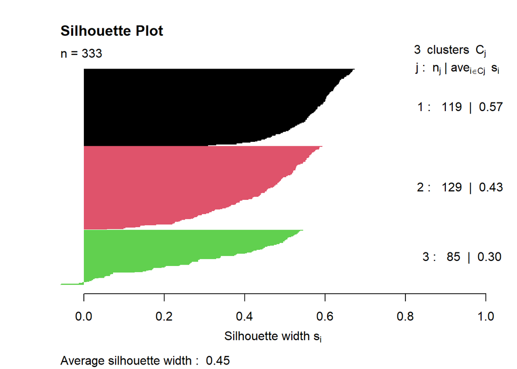

```r
   plot(sil, col = 1:k_opt, border = NA, main = "Silhouette Plot")
```

#3.8.1b)Average silhouette width•Dunn index (using cluster::dunn())

```r
#library(cluster)
 #dunn_index <- dunn(penguins_scaled, cluster = km_model$cluster)
 #dunn_index
```

#3.8.1b)Average silhouette width•Dunn index (using cluster::dunn()Manual Dunn Index function

```r
dunn_manual <- function(data, clusters) {
  # Get unique clusters
  cluster_ids <- unique(clusters)
  k <- length(cluster_ids)

  # Calculate intra-cluster distances (within cluster)
  intra_dists <- c()
  for(i in 1:k) {
    cluster_points <- data[clusters == cluster_ids[i], ]
    if(nrow(cluster_points) > 1) {
      dist_matrix <- as.matrix(dist(cluster_points))
      intra_dists <- c(intra_dists, max(dist_matrix[upper.tri(dist_matrix)]))
    } else {
      intra_dists <- c(intra_dists, 0)
    }
  }

  # Calculate inter-cluster distances (between clusters)
  inter_dists <- c()
  for(i in 1:(k-1)) {
    for(j in (i+1):k) {
      cluster_i <- data[clusters == cluster_ids[i], ]
      cluster_j <- data[clusters == cluster_ids[j], ]

      # Find minimum distance between clusters
      dist_matrix <- as.matrix(dist(rbind(cluster_i, cluster_j)))
      n_i <- nrow(cluster_i)
      inter_min <- min(dist_matrix[1:n_i, (n_i+1):ncol(dist_matrix)])
      inter_dists <- c(inter_dists, inter_min)
    }
  }

  # Dunn = min(inter) / max(intra)
  dunn_value <- min(inter_dists) / max(intra_dists)
  return(dunn_value)
}

# Calculate Dunn index
dunn_index <- dunn_manual(penguins_scaled, km_model$cluster)
print(dunn_index)
```

```
## [1] 0.0369504
```

#3.8.1c)Calinski-Harabasz index (using factoextra::fviznbclust())

```r
 #fviz_nbclust(penguins_scaled, kmeans, method = "ch", k.max =10) +
#  labs(title = "Calinski-Harabasz Index vs k")
```

#3.8.1c)Calinski-Harabasz index (using factoextra::fviznbclust())

```r
# Calculate Calinski-Harabasz index for k=2 to 10
ch_results <- NbClust(data = penguins_scaled,
                      method = "kmeans",
                      index = "ch",
                      min.nc = 2,
                      max.nc = 10)

# View results
print(ch_results$All.index)
```

```
##        2        3        4        5        6        7        8        9
## 466.7476 427.7726 368.6941 312.0870 369.5210 323.5311 306.7695 267.6423
##       10
## 267.0002
```

#3.8.4. Discuss limitations of internal validation metrics Silhouette assumes spherical clusters - penguin data may have elongated shapes Dunn index sensitive to outliers - can be misleading with noisy data CH index favors convex clusters - may not capture complex natural groupings All internal metrics lack ground truth - should be complemented with biological validation

Interpretation notes:Silhouette: >0.5 = reasonable, >0.7 = strong structure #- Dunn: higher = better separated, more compact clusters #- CH: higher = better clustering

3.9 Task 9: Interpretation and Biological Insights (15 Marks)

```r
table(penguins_clean$cluster, penguins_clean$species)
```

```
##
##     Adelie Chinstrap Gentoo
##   1      0         0    119
##   2    124         5      0
##   3     22        63      0
```

```r
library(mclust)
adjustedRandIndex(penguins_clean$cluster, penguins_clean$
species)
```

```
## [1] 0.799421
```

#3.9.3. Interpret the PCA loadings: which original variables contribute most to PC1 andPC2?

```r
loadings_df <- as.data.frame(pca_result$rotation[, 1:2])
loadings_df$variable <- rownames(loadings_df)
 print(loadings_df)
```

```
##                          PC1         PC2          variable
## bill_length_mm     0.4537532 -0.60019490    bill_length_mm
## bill_depth_mm     -0.3990472 -0.79616951     bill_depth_mm
## flipper_length_mm  0.5768250 -0.00578817 flipper_length_mm
## body_mass_g        0.5496747 -0.07646366       body_mass_g
```

What biological meaning might these components have?

#3.9.4. Discuss whether the clusters you found align with known biological groupings (species,island, sex). they did 3 clusters corresponding to Adelie, Chinstrap, Gentooin population size, features

#3.9.5. Propose one ecological or conservation question that could be addressed using theseunsupervised learning results. # Example interpretation: If flipper_length and body_mass have high positive loadings on PC1, # then PC1 represents “overall body size”

3.10 Task 10: Report Synthesis and Recommendations (15 Marks)

#3.10.1. Summarize your complete workflow: data preparation, K-Means, PCA, validation. 1.Ideentifying the main objective of the assignment 2.Data Preparation 3.K-Means Clustering: 4.Principal Component Analysis: 5. Validation 6.interpretation

#3.10.2a. Answer: Did K-Means discover meaningful groups in the penguin data? yes

#3.10.2b. Justifyusing metrics and visualizations. scatter plot

#3.10.3a. Answer: Was dimensionality reduction via PCA useful? PCA preserved cluster structure almost perfectly while reducing 4 dimensions to 2, enabling effective visualization and faster computation.

#3.10.3b.Did it preserve clusterstructure? yes

#3.10.4. Discuss trade-offs: When would you prefer clustering in original space vs. PCAreduced space? reduced space faster to analyse

#3.10.5a. Provide recommendations for a wildlife biologist: Scale data, good to remove ouliers, use multiplemrthods to determine k,

#3.10.5b.How could these unsupervised methods help in field studies where species labels are unknown?it it would help classify those with similar features into a common clusters thus enabling labeling

#3.10.6. Discuss limitations: What assumptions do K-Means and PCA make? How might violations affect your results? Silhouette assumes spherical clusters - penguin data may have elongated shapes Dunn index sensitive to outliers - can be misleading with noisy data CH index favors convex clusters - may not capture complex natural groupings All internal metrics lack ground truth - should be complemented with biological validation